# Exploring Food Deserts

Team 1 : Abishek Chiffon, Keerthana Aravindhan, Mowzli Sre Mohan Dass, Robert Williams

2023-10-26

- Limited access to supermarkets, supercenters, grocery stores, or other sources of healthy and affordable food may make it harder for some people to eat a healthy diet in this country and to achieve food security.
- Expanding the availability of nutritious and affordable food by developing and equipping grocery stores, small retailers, corner markets and farmers’ markets in communities with limited access is an important part of the Healthy Food Financing Initiative.

# Data Loading and Preprocessing

Viewing Food desert dataset:

```r
# Loading data
data <- data.frame(read.csv("food_access_research_atlas_2015.csv"))
knitr::kable(head(data, 5), format ='markdown')
```

| CensusTract | State | County | Urban | POP2010 | OHU2010 | GroupQuartersFlag | NUMGQTRS | PCTGQTRS | LILATracts_1And10 | LILATracts_halfAnd10 | LILATracts_1And20 | LILATracts_Vehicle | HUNVFlag | LowIncomeTracts | PovertyRate | MedianFamilyIncome | LA1and10 | LAhalfand10 | LA1and20 | LATracts_half | LATracts1 | LATracts10 | LATracts20 | LATractsVehicle_20 | LAPOP1_10 | LAPOP05_10 | LAPOP1_20 | LALOWI1_10 | LALOWI05_10 | … |
| --- | --- | --- | --- | --- | --- | --- | --- | --- | --- | --- | --- | --- | --- | --- | --- | --- | --- | --- | --- | --- | --- | --- | --- | --- | --- | --- | --- | --- | --- | --- |
| 1.001e+09 | Alabama | Autauga | 1 | 1912 | 693 | 0 | 0 | 0.00000 | 0 | 0 | 0 | 0 | 0 | 0 | 10.0 | 74750 | 1 | 1 | 1 | 1 | 1 | 0 | 0 | 0 | 1357.48 | 1732.2 | 1357.48 | 322.08 | 411.69 | … |
| 1.001e+09 | Alabama | Autauga | 1 | 2170 | 743 | 0 | 181 | 0.08341 | 0 | 0 | 0 | 0 | 0 | 0 | 18.2 | 51875 | 0 | 1 | 0 | 1 | 0 | 0 | 0 | 0 | 483.43 | 1410.4 | 483.43 | 145.14 | 475.31 | … |
| 1.001e+09 | Alabama | Autauga | 1 | 3373 | 1256 | 0 | 0 | 0.00000 | 0 | 0 | 0 | 0 | 0 | 0 | 19.1 | 52905 | 1 | 1 | 1 | 1 | 1 | 0 | 0 | 0 | 1417.87 | 2764.6 | 1417.87 | 696.64 | 1350.18 | … |
| 1.001e+09 | Alabama | Autauga | 1 | 4386 | 1722 | 0 | 0 | 0.00000 | 0 | 0 | 0 | 0 | 0 | 0 | 3.3 | 68079 | 1 | 1 | 1 | 1 | 1 | 0 | 0 | 0 | 1363.47 | 3651.1 | 1363.47 | 409.59 | 1067.84 | … |
| 1.001e+09 | Alabama | Autauga | 1 | 10766 | 4082 | 0 | 181 | 0.01681 | 0 | 0 | 0 | 0 | 1 | 0 | 8.5 | 77819 | 1 | 1 | 1 | 1 | 1 | 0 | 0 | 1 | 2643.10 | 7778.4 | 2643.10 | 623.08 | 1913.45 | … |

# Summary of the dataset:

```r
summary(data)
```

```
##   CensusTract          State              County              Urban
##  Min.   :1.00e+09   Length:72864       Length:72864       Min.   :0.000
##  1st Qu.:1.21e+10   Class :character   Class :character   1st Qu.:1.000
##  Median :2.71e+10   Mode  :character   Mode  :character   Median :1.000
##  Mean   :2.78e+10                                         Mean   :0.757
##  3rd Qu.:4.10e+10                                         3rd Qu.:1.000
##  Max.   :5.60e+10                                         Max.   :1.000
##     POP2010         OHU2010      GroupQuartersFlag    NUMGQTRS
##  Min.   :    0   Min.   :    0   Min.   :0.00000   Min.   :    0
##  1st Qu.: 2884   1st Qu.: 1102   1st Qu.:0.00000   1st Qu.:    0
##  Median : 4002   Median : 1521   Median :0.00000   Median :    7
##  Mean   : 4237   Mean   : 1602   Mean   :0.00708   Mean   :  110
##  3rd Qu.: 5323   3rd Qu.: 2018   3rd Qu.:0.00000   3rd Qu.:   63
##  Max.   :37452   Max.   :16043   Max.   :1.00000   Max.   :19496
##     PCTGQTRS       LILATracts_1And10 LILATracts_halfAnd10 LILATracts_1And20
##  Min.   :0.00000   Min.   :0.000     Min.   :0.000        Min.   :0.000
##  1st Qu.:0.00000   1st Qu.:0.000     1st Qu.:0.000        1st Qu.:0.000
##  Median :0.00178   Median :0.000     Median :0.000        Median :0.000
##  Mean   :0.02696   Mean   :0.127     Mean   :0.282        Mean   :0.111
##  3rd Qu.:0.01552   3rd Qu.:0.000     3rd Qu.:1.000        3rd Qu.:0.000
##  Max.   :1.00000   Max.   :1.000     Max.   :1.000        Max.   :1.000
##  LILATracts_Vehicle    HUNVFlag     LowIncomeTracts  PovertyRate
##  Min.   :0.000      Min.   :0.000   Min.   :0.000   Min.   :  0.0
##  1st Qu.:0.000      1st Qu.:0.000   1st Qu.:0.000   1st Qu.:  7.0
##  Median :0.000      Median :0.000   Median :0.000   Median : 13.2
##  Mean   :0.149      Mean   :0.224   Mean   :0.424   Mean   : 16.6
##  3rd Qu.:0.000      3rd Qu.:0.000   3rd Qu.:1.000   3rd Qu.: 22.7
##  Max.   :1.000      Max.   :1.000   Max.   :1.000   Max.   :100.0
##  MedianFamilyIncome    LA1and10      LAhalfand10       LA1and20
##  Min.   :     0     Min.   :0.000   Min.   :0.000   Min.   :0.000
##  1st Qu.: 44837     1st Qu.:0.000   1st Qu.:0.000   1st Qu.:0.000
##  Median : 60893     Median :0.000   Median :1.000   Median :0.000
##  Mean   : 67432     Mean   :0.378   Mean   :0.682   Mean   :0.339
##  3rd Qu.: 82763     3rd Qu.:1.000   3rd Qu.:1.000   3rd Qu.:1.000
##  Max.   :250000     Max.   :1.000   Max.   :1.000   Max.   :1.000
##  LATracts_half     LATracts1       LATracts10      LATracts20
##  Min.   :0.000   Min.   :0.000   Min.   :0.000   Min.   :0.00000
##  1st Qu.:0.000   1st Qu.:0.000   1st Qu.:0.000   1st Qu.:0.00000
##  Median :1.000   Median :0.000   Median :0.000   Median :0.00000
##  Mean   :0.638   Mean   :0.334   Mean   :0.044   Mean   :0.00532
```

[output cut: 204 more lines]

```
##  Max.   :11845   Max.   :17271   Max.   :28983   Max.   :16804
##    TractAsian      TractNHOPI       TractAIAN       TractOMultir
##  Min.   :    0   Min.   :   0.0   Min.   :   0.0   Min.   :   0
##  1st Qu.:   17   1st Qu.:   0.0   1st Qu.:   7.0   1st Qu.:  83
##  Median :   57   Median :   1.0   Median :  15.0   Median : 184
##  Mean   :  201   Mean   :   7.4   Mean   :  40.2   Mean   : 386
##  3rd Qu.:  188   3rd Qu.:   5.0   3rd Qu.:  33.0   3rd Qu.: 446
##  Max.   :10485   Max.   :3491.0   Max.   :9009.0   Max.   :8839
##  TractHispanic     TractHUNV      TractSNAP
##  Min.   :    0   Min.   :   0   Min.   :   0
##  1st Qu.:   87   1st Qu.:  37   1st Qu.:  69
##  Median :  240   Median :  84   Median : 158
##  Mean   :  693   Mean   : 145   Mean   : 207
##  3rd Qu.:  746   3rd Qu.: 172   3rd Qu.: 293
##  Max.   :15420   Max.   :6176   Max.   :2152
```

# Exposition and Curation

## About the Dataset:

This information on supermarket availability at different distances was taken from the Food Access Research Atlas. This data gives a rich detailed summary because it measures access by the Census-Tract. Data on food access was linked with information on age, race, location (rural or urban), income and vehicle access.

- USDA calls Low income Low access areas as Food deserts.
- Census tract level : subdivisions of counties.

## Limitations of the Dataset:

The dataset lacks variables to monitor the median household income and vehicle accessibility across different ethnic groups. It is crucial to note that the term “vehicle access” in this context does not necessarily imply the absence of vehicles at a residence; rather, individuals are deemed to have access to a vehicle if public transportation is readily available to them. Additionally, there are no variables present to explicitly denote households without any vehicles.

## How was the information gathered?

Beside knowing the dataset requirements for Project 1. The idea of Food Desert came from one of our team members that did some volunteer work on a number of community project in past.

This data set is maintained by the Economic Research Service (ERS) and U.S. Department of Agriculture (USDA). Thus, it is pulled from the Food Access Research Atlas, and contains information on supermarket access at various distances. This data measures access by the Census-Tract, and as such provides a fairly granular overview.

## Previous analysis on Food deserting:

- An article titled `What Are Food Deserts and Why Do They Exit? (FFAC Staff, 2022)` was the subject of an analysis that was relevant to the dataset’s content.
- The report highlights a sobering reality: the challenge of envisioning life without access to nutritious food is a daily struggle for numerous individuals. The issue does not stem from a lack of food production; rather, it’s the unfortunate reality that millions of people, particularly those residing in “food deserts,” face a profound lack of access to wholesome sustenance.

## Research contribution to question development:

The data in the article, “What Are Food Deserts and Why Do They Exits?,” had some of the variables, such as census tract and areas that are low-income and low-access in our food desert dataset. It also helped to frame achievable questions.

## Additional information that would be beneficial:

According to another article, “Food Research & Action Center Calls for WIC Funding, SNAP Benefit Adequacy as Rates of Hunger Rise” (FFAC Staff, 2023), from Food Research & Action Center (FRAC), stated today by the U.S. Department of Agriculture’s Economic Research Service (ERS), that the COVID-19 pandemic relief efforts caused hunger in America to decline the previous year, but it surged in 2022.

- So additional information on how covid affected food desert status would be beneficial.
- The most recent year’s dataset is missing, which could provide light on the food desert impact currently.

# EDA Analysis:

## Question 1:

### Geographic Distribution of State/County wise Prevelance of Food Deserts

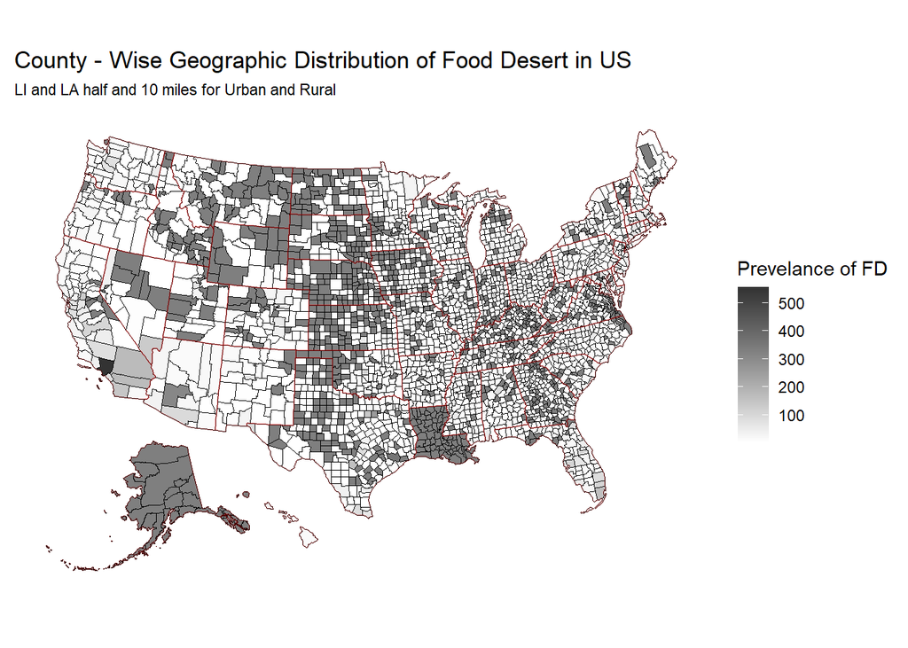

```r
plot_map <- function(dataset, colx, region, subx) {
  grpddata <- dataset %>%
    filter(.data[[colx]] == 1) %>% # Filtering the food desert flags
    group_by(State, County) %>% # Grouping by State and County
    reframe(full = State, count = sum(.data[[colx]]))  # Reframing to dataframe for Plotting
  grpddata$county <-
    paste(grpddata$County, "County") # Adding " County" text to support prerequisite of the plot_usmap() counties
  grpddata <-
    distinct(grpddata, .keep_all = TRUE) %>% select(full, county, count) # Ignoring the duplicates and selecting particular columns to supply the plot_usmap()
  counties_df <-
    us_map("counties") %>% select(fips, full, county) %>% distinct() # Getting the FIPS data of the counties. Mandatory for plotting in maps. Available from the us_map() dataframe built-in with the plot_usmap() library
  merged_df <-
    grpddata %>% right_join(counties_df, by = c("county", "full")) # Right joining the dataframes to get relevant FIPS code

  if (region == "State") {
    merged_df <-
      merged_df %>% select(-fips) %>% rename(state = full) # Changing the structure for State wise plotting
  }
  state_map <-
    plot_usmap("states", color = "#ff000030", size = 0.01)

  counties_map <- plot_usmap(
    data = merged_df,
    values = "count",
    color = "black",
    size = 0.1
  )

  # Merging both the plots using ggplot and rendering the combined map using geom_polygon()
  ggplot() +
    geom_polygon(
      data = counties_map[[1]],
      aes(
        x = x,
        y = y,
        group = group,
        fill = counties_map[[1]]$count,
      ),
      color = "black",
      size = 0.1
    ) +
    geom_polygon(
      data = state_map[[1]],
      aes(x = x,
          y = y,
          group = group),
      color = "#ff000030",
      fill = alpha(0.01)
    ) +
    coord_equal() +
    theme(
      panel.grid = element_blank(),
      axis.title = element_blank(),
      axis.text = element_blank(),
      axis.ticks = element_blank(),
      strip.text = element_blank(),
      plot.subtitle = element_text(size = rel(0.8)),
      panel.background = element_rect(fill = "white"),

    ) +
    scale_fill_gradient(low = 'white', high = 'grey20') +
    labs(
      title = paste(region, "- Wise Geographic Distribution of Food Desert in US"),
      subtitle = subx,
      fill = "Prevelance of FD"
    )
}


plot_map(data, colx = "LILATracts_halfAnd10", region="County", subx="LI and LA half and 10 miles for Urban and Rural")
```

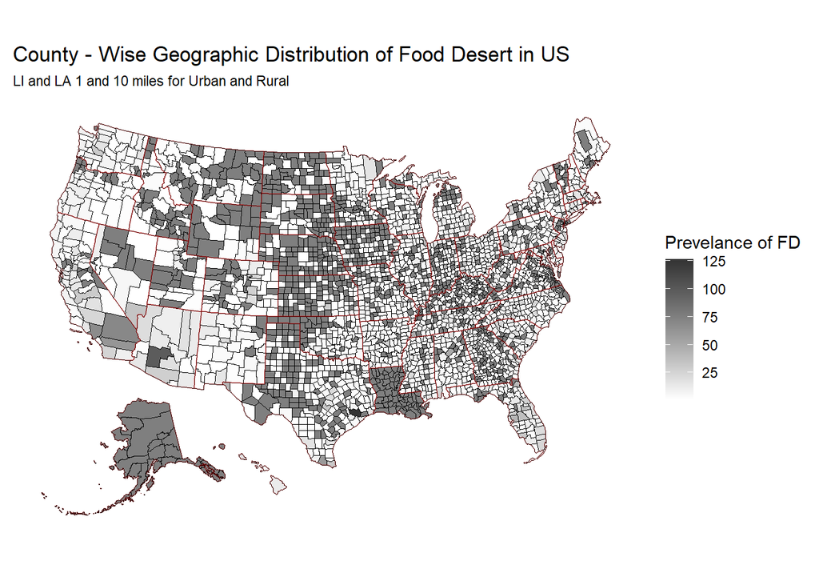

```r
plot_map(data, colx = "LILATracts_1And10", region="County", subx="LI and LA 1 and 10 miles for Urban and Rural")
```

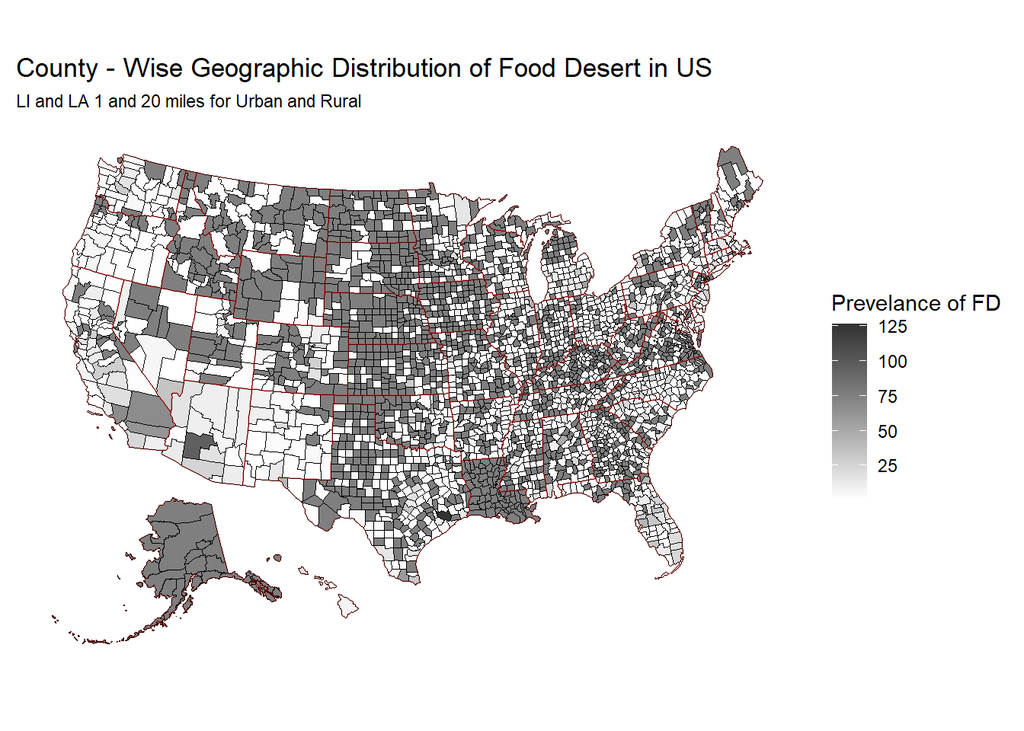

```r
plot_map(data, colx = "LILATracts_1And20", region="County", subx="LI and LA 1 and 20 miles for Urban and Rural")
```

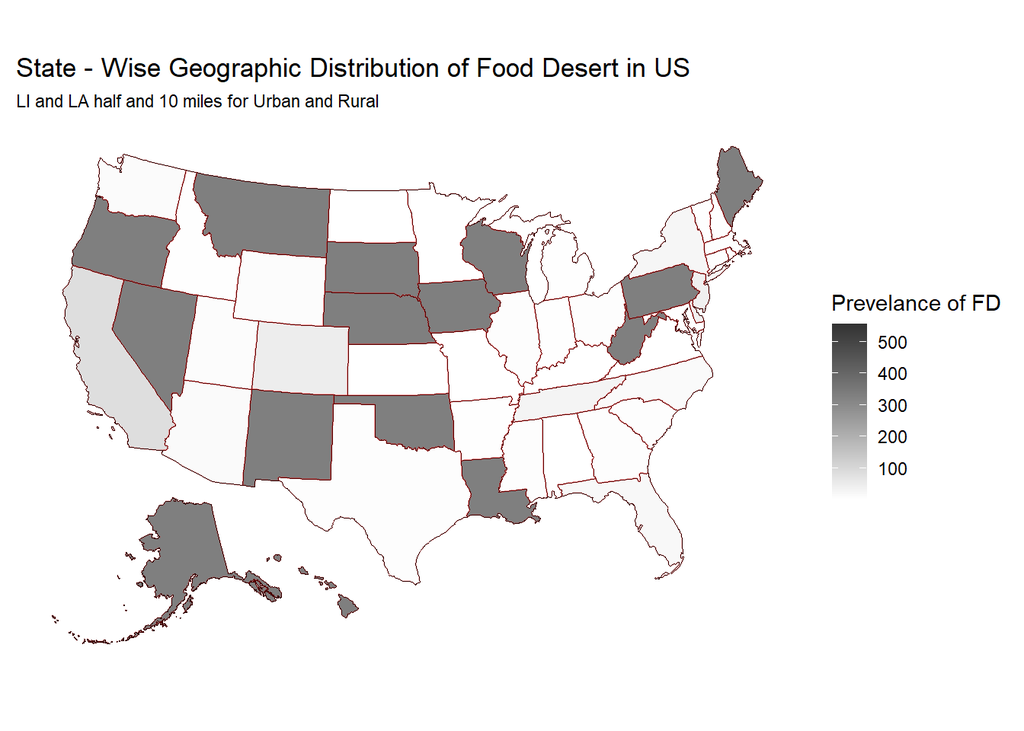

```r
plot_map(data, colx = "LILATracts_halfAnd10", region="State", subx="LI and LA half and 10 miles for Urban and Rural")
```

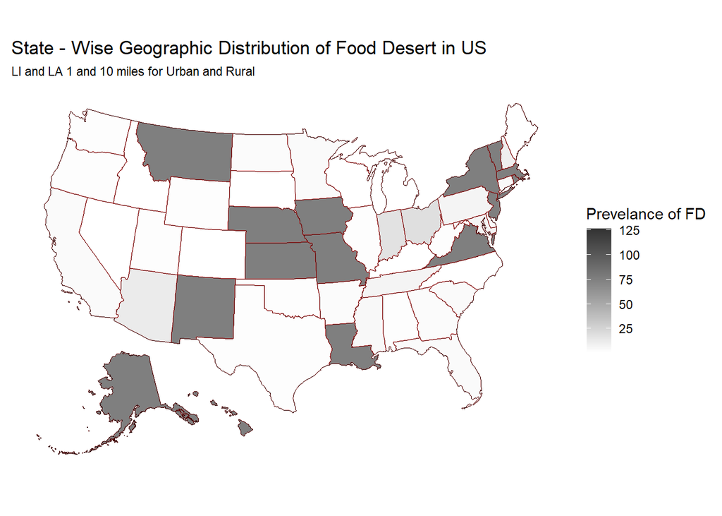

```r
plot_map(data, colx = "LILATracts_1And10", region="State", subx="LI and LA 1 and 10 miles for Urban and Rural")
```

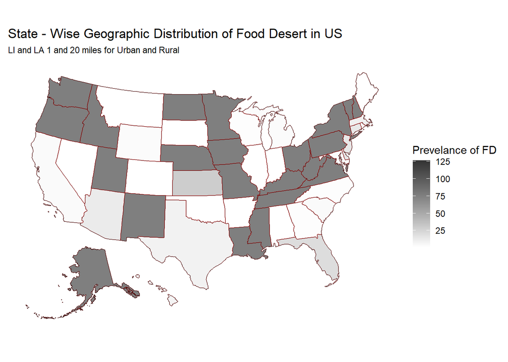

```r
plot_map(data, colx = "LILATracts_1And20", region="State", subx="LI and LA 1 and 20 miles for Urban and Rural")
```

Unique states and counties are represented in the dataset.

```r
unique_states <- data %>% group_by(State) %>% distinct(State) # Grouping by State and using distinct() to get unique states
unique_counties <- data %>% group_by(State, County) %>% distinct(County)
# Grouping by both State and County and then
# using distinct() to get unique states. Because directly Grouping the counties will result in lesser results as different
# counties in different States can exists with the same name
```

**Total census tracts included in the dataset : 72864**

```r
unique_states <- data %>% group_by(State) %>% distinct(State) # Grouping by State and using distinct() to get unique states
unique_counties <- data %>% group_by(State, County) %>% distinct(County)
# Grouping by both State and County and then
# using distinct() to get unique states. Because directly Grouping the counties will result in lesser results as different
# counties in different States can exists with the same name
```

## Question 2:

Urban vs Rural Classification impacts :

```r
total_count <- nrow(data)
urban_count <- nrow(data %>% filter(Urban == 1))
rural_count <- nrow(data %>% filter(Urban == 0))
urban_food_desert_count <- nrow(data %>% filter(Urban == 1, LILATracts_1And10 == 1))
rural_food_desert_count <- nrow(data %>% filter(Urban == 0, LILATracts_1And10 == 1))

urban_percentage <- urban_count / total_count * 100
rural_percentage <- rural_count / total_count * 100
urban_food_desert_percentage <- urban_food_desert_count / urban_count * 100
rural_food_desert_percentage <- rural_food_desert_count / rural_count * 100
overall_percentage <- (urban_food_desert_count + rural_food_desert_count) / total_count * 100
```

There are 7905 Urban Food Deserts.

There are 1340 Rural Food Deserts.

The Urban tracts constitute 75.72% of the total Census tracts. The Rural tracts constitute 24.28% of the total Census tracts.

Based on the dataset, it is found that 14.33% of the Urban tracts are food deserts. And 7.57 % of the Rural tracts are food deserts.

Overall, 12.69% are food deserts based on the analysis made over the dataset.

**From the analysis, it is evident that Food Deserts are more common in the Urban Areas, due to many factors like Population, Poverty Rates, Low Access and Low Income tracts**

## Question 3:

### Characteristics of Areas with Group Quarters

`Group Quarters` : Places where people live or stay in a group. Living arrangement that is owned or managed by an entity or organization providing housing and/or services for the residents.

- Percentage of Group Quarters in Food desert regions:

```r
data$GroupQuartersFlag <- as.factor(data$GroupQuartersFlag)
data$LILATracts_1And10 <- as.factor(data$LILATracts_1And10)

GroupQuarters_LILA <- data[ (data$GroupQuartersFlag == 1 & data$LILATracts_1And10 == 1), c("GroupQuartersFlag", "LILATracts_1And10")]
NonGroupQuarters_LILA <- data[data$GroupQuartersFlag == 0 & data$LILATracts_1And10 == 1, c("GroupQuartersFlag", "LILATracts_1And10")]

data1 = data.frame()
Percentage_GroupQuarters_LILA = nrow(GroupQuarters_LILA)/(sum(nrow(GroupQuarters_LILA)+ nrow(NonGroupQuarters_LILA)))*100
Percentage_NonGroupQuarters_LILA = nrow(NonGroupQuarters_LILA)/(sum(nrow(GroupQuarters_LILA)+ nrow(NonGroupQuarters_LILA)))*100
data1 <- rbind(data1, Percentage_GroupQuarters_LILA)
data1 <- rbind(data1, Percentage_NonGroupQuarters_LILA)
GroupQuartersFlag = c(1,0)
data1 <- cbind(data1, GroupQuartersFlag)
colnames(data1) <- c('Percentage', 'GroupQuartersFlag')
```

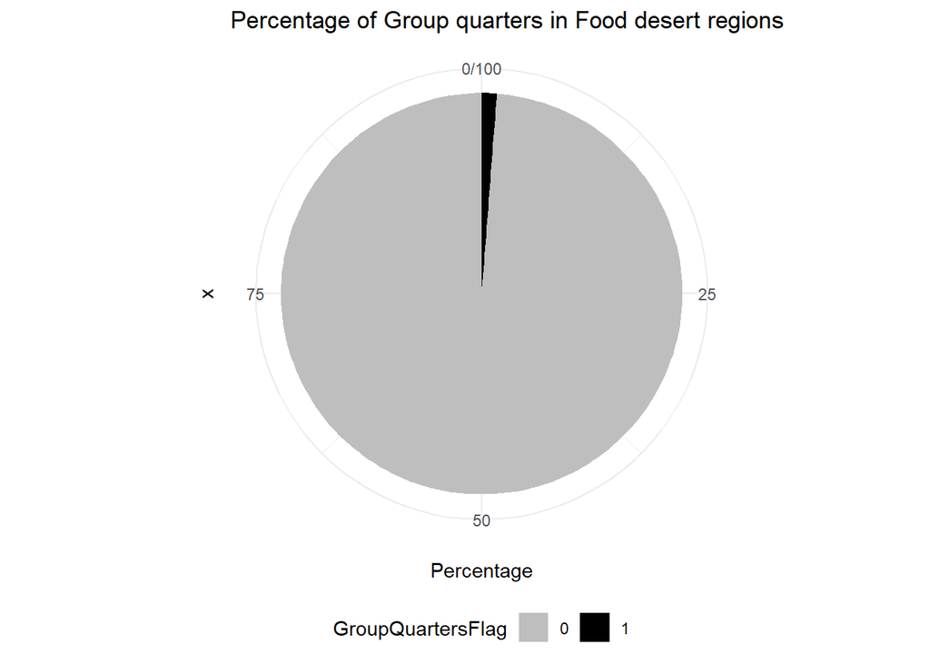

```r
library(ggplot2)
pie_chart <- ggplot(data1, aes(x = "", y = Percentage, fill = factor(GroupQuartersFlag))) +
  geom_bar(stat = "identity", width = 1) +
  coord_polar(theta = "y") +
  labs(title = "Percentage of Group quarters in Food desert regions",
       fill = "GroupQuartersFlag") +
  scale_fill_manual(values = c("0" = "grey", "1" = "black"), labels = c("0", "1")) +
  theme_minimal() +
  theme(legend.position = "bottom")
print(pie_chart)
```

The proportion of group quarters is lower across all food deserts. Additionally, when compared to the entire Groupquarters,a smaller fraction of Groupquarters are located in food deserted areas.

### Percentage of Group quarters by state:

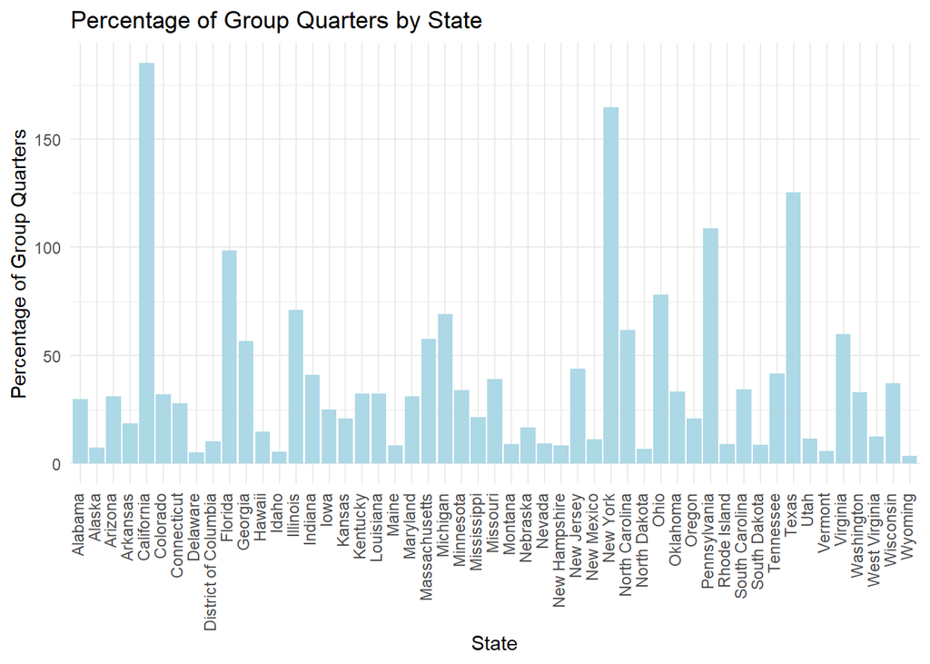

```r
data$State <- as.factor(data$State)

bar_chart <- ggplot(data, aes(x = State, y = PCTGQTRS)) +
  geom_bar(stat = "identity", fill = "lightblue") +
  labs(title = "Percentage of Group Quarters by State",
       x = "State",
       y = "Percentage of Group Quarters") +
  theme_minimal() +
  theme(axis.text.x = element_text(angle = 90, hjust = 1, vjust=0.2))

print(bar_chart)
```

- California and New York have more group quarters tracts.
- Wyoming and Delaware are states with least group quarters.

### Correlation between Group quarters and the prevalence of Food deserts:

Testing using chi-square (GOF) between 2 categorical variables (GroupQuartersFlag and LILATracts_1And10):

- Null Hypothesis (H0): There is no association between the two categorical variables
- Alternative Hypothesis (H1): There is an association between the two categorical variables

Significance level $\alpha$ = 0.05

```r
contingency_table <- table(data$GroupQuartersFlag, data$LILATracts_1And10)

chi_squared_test_result <- chisq.test(contingency_table)
chi_squared_test_result
```

```
##
##  Pearson's Chi-squared test with Yates' continuity correction
##
## data:  contingency_table
## X-squared = 37.3, df = 1, p-value = 1e-09
```

Due to the extremely low p value, H0 is rejected. This shows a large discrepancy between observed and predicted frequencies for the “GroupQuartersFlag” and “LILATracts_1And10” variables, indicating that the observed data does not follow the expected distribution.

Therefore, there is a **significant association or correlation** between “GroupQuartersFlag” and “LILATracts_1And10.”

### Group quarters link with other variables in data1

- Bar chart to compare the Group quarters in Urban and Rural.

```r
data$GroupQuartersFlag <- as.factor(data$GroupQuartersFlag)
data$Urban <- as.factor(data$Urban)

GroupQuarters <- data[data$GroupQuartersFlag == 1, c("GroupQuartersFlag", "Urban")]
```

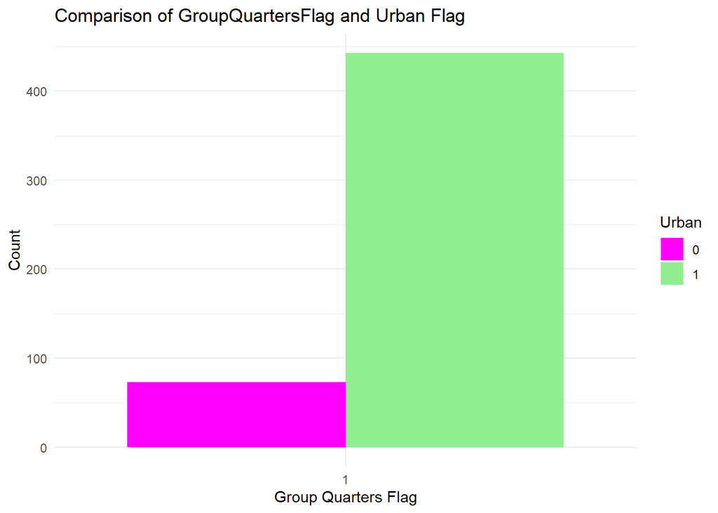

```r
bar_chart <- ggplot(GroupQuarters, aes(x = GroupQuartersFlag, fill = Urban)) +
  geom_bar(position = "dodge") +
  labs(title = "Comparison of GroupQuartersFlag and Urban Flag",
       x = "Group Quarters Flag",
       y = "Count") +
  scale_fill_manual(values = c("1" = "lightgreen", "0" = "magenta")) +
  theme_minimal()

print(bar_chart)
```

Group quarters are more in urban compared to Rural.

- How is Groupquarters associated with Poverty rate:

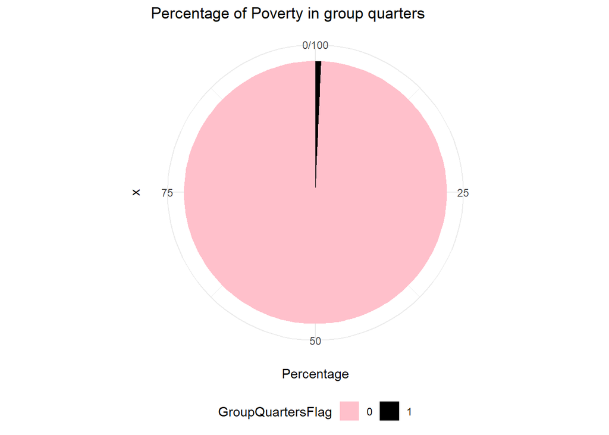

```r
data2 = data.frame()
Percentage_GroupQuarters_Poverty = nrow(GroupQuarters_Poverty)/(sum(nrow(GroupQuarters_Poverty)+ nrow(NonGroupQuarters_Poverty)))*100
Percentage_NonGroupQuarters_Poverty = nrow(NonGroupQuarters_Poverty)/(sum(nrow(GroupQuarters_Poverty)+ nrow(NonGroupQuarters_Poverty)))*100
data2 <- rbind(data2, Percentage_GroupQuarters_Poverty)
data2 <- rbind(data2, Percentage_NonGroupQuarters_Poverty)
GroupQuartersFlag = c(1,0)
data2 <- cbind(data2, GroupQuartersFlag)
colnames(data2) <- c('Percentage', 'GroupQuartersFlag')

pie_chart <- ggplot(data2, aes(x = "", y = Percentage, fill = factor(GroupQuartersFlag))) +
  geom_bar(stat = "identity", width = 1) +
  coord_polar(theta = "y") +
  labs(title = "Percentage of Poverty in group quarters",
       fill = "GroupQuartersFlag") +
  scale_fill_manual(values = c("0" = "pink", "1" = "black"), labels = c("0", "1")) +
  theme_minimal() +
  theme(legend.position = "bottom")
print(pie_chart)
```

Poverty rate is more in Non Group Quarters tracts.

- Applying T-Test on “PovertyRate” with respect to Group quarters:
  - Null Hypothesis (H0): The average Poverty rate are the same for with and without group quarters .
  - Alternative Hypothesis (H1): The average Poverty rate are different for with and without group quarters .

  Significance level $\alpha$ = 0.05

```r
t_test_result <- t.test(data_outliers$PovertyRate ~ data_outliers$GroupQuartersFlag)
t_test_result
```

```
##
##  Welch Two Sample t-test
##
## data:  data_outliers$PovertyRate by data_outliers$GroupQuartersFlag
## t = 5.21, df = 368, p-value = 3.2e-07
## alternative hypothesis: true difference in means between group 0 and group 1 is not equal to 0
## 95 percent confidence interval:
##  2.4367 5.3935
## sample estimates:
## mean in group 0 mean in group 1
##          15.210          11.295
```

p value is less than $\alpha$ (0.05). Thus, Null hypothesis is rejected, indicating that there is a significant difference between the means of poverty rate of Groupquarters and nongroupquarters.

`**Analysis**`

- **Group quarters are more prevalent in Non-Food deserted regions and have a lower poverty incidence.**
- **This begs the question of why food sellers choose these kinds of neighborhood settings for their stores. Or more specifically, are they even relocating their current stores to these affluent areas?**
- **Consequently, “supermarket redlining” is becoming a common practice.**

## Question 4:

### Analyzing Poverty Rate in Different Tracts

The mean poverty rate is 26.5 for food deserts and for non-food deserts it is 15.1. So the Poverty rate in food deserts is 75% higher than non-food deserts. Poverty rate in Low access area is 14.2 whereas in non-low access area is 18.0.

### Count of Low Income tracts in Low access tracts

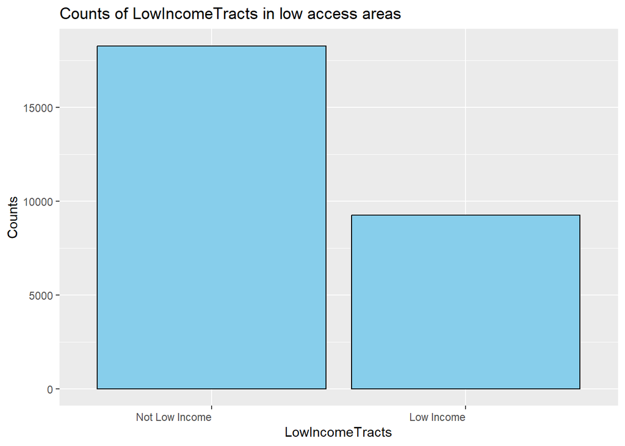

```r
# Filtering data for rows where LA1and10 is 1
filtered_data <- data[data$LA1and10 == 1, ]

# Calculating value counts for LowIncomeTracts
value_counts <- table(filtered_data$LowIncomeTracts)

# Converting to data frame for ggplot
value_counts_df <- as.data.frame(value_counts)
names(value_counts_df) <- c("LowIncomeTracts", "Counts")

# Creating custom labels
value_counts_df$Labels <- ifelse(value_counts_df$LowIncomeTracts == 0, "Not Low Income",
                                 ifelse(value_counts_df$LowIncomeTracts == 1, "Low Income", value_counts_df$LowIncomeTracts))

# Creating the bar plot
p <- ggplot(value_counts_df, aes(x = reorder(Labels, -Counts), y = Counts)) +
  geom_bar(stat = "identity", fill = "skyblue", color = "black") +
  labs(title = "Counts of LowIncomeTracts in low access areas", x = "LowIncomeTracts", y = "Counts") +
  theme(axis.text.x = element_text(angle = 0, hjust = 1))

# Showing the plot
print(p)
```

### Relationship between states and poverty rate:

- Statewise average poverty rate

```r
states_pov <- data %>%
  group_by(State) %>%
  summarise(avg_poverty_rate = mean(PovertyRate, na.rm = TRUE)) %>%
  arrange(desc(avg_poverty_rate))

print(states_pov)
```

```
## # A tibble: 51 × 2
##    State                avg_poverty_rate
##    <fct>                           <dbl>
##  1 Mississippi                      24.6
##  2 Louisiana                        21.6
##  3 Alabama                          21.2
##  4 New Mexico                       20.8
##  5 Georgia                          20.5
##  6 Arkansas                         20.4
##  7 Kentucky                         20.1
##  8 District of Columbia             19.7
##  9 West Virginia                    19.6
## 10 South Carolina                   19.6
## # ℹ 41 more rows
```

```r
states_pov$norm_poverty_rate <- scale(states_pov$avg_poverty_rate)

print(states_pov)
```

```
## # A tibble: 51 × 3
##    State                avg_poverty_rate norm_poverty_rate[,1]
##    <fct>                           <dbl>                 <dbl>
##  1 Mississippi                      24.6                  2.52
##  2 Louisiana                        21.6                  1.65
##  3 Alabama                          21.2                  1.53
##  4 New Mexico                       20.8                  1.39
##  5 Georgia                          20.5                  1.32
##  6 Arkansas                         20.4                  1.27
##  7 Kentucky                         20.1                  1.21
##  8 District of Columbia             19.7                  1.09
##  9 West Virginia                    19.6                  1.06
## 10 South Carolina                   19.6                  1.05
## # ℹ 41 more rows
```

The poverty rate is normalised to find the correlation between poverty rate of states and food deserts

- Identify states with high poverty

```r
threshold <- quantile(states_pov$norm_poverty_rate, 0.85)
states_high_pov <- states_pov %>%
  filter(norm_poverty_rate > threshold)

print(states_high_pov)
```

```
## # A tibble: 8 × 3
##   State                avg_poverty_rate norm_poverty_rate[,1]
##   <fct>                           <dbl>                 <dbl>
## 1 Mississippi                      24.6                  2.52
## 2 Louisiana                        21.6                  1.65
## 3 Alabama                          21.2                  1.53
## 4 New Mexico                       20.8                  1.39
## 5 Georgia                          20.5                  1.32
## 6 Arkansas                         20.4                  1.27
## 7 Kentucky                         20.1                  1.21
## 8 District of Columbia             19.7                  1.09
```

To address the question whether states with high poverty rate also have high number of food deserts, we are filtering only the states above 85th percentile of poverty rate.

- Correlation between states and food deserts

High Poverty States and food desert count

Using Pearson Correlation:

**Null hypothesis**: There is no correlation between High poverty rate states with count of their food desert.

**Alternate hypothesis** : There is Correlation between High poverty rate states with count of their food desert.

```r
# Calculate statewise food desert count
states_food_deserts <- data %>%
  filter(LILATracts_1And10 == 1) %>%
  count(State)
#print(states_food_deserts)

# Normalize food desert counts
states_food_deserts$norm_count <- scale(states_food_deserts$n)

merged_data <- inner_join(states_high_pov, states_food_deserts, by = "State")
merged_data_all <- inner_join(states_pov, states_food_deserts, by = "State")
# Get correlation
# There is no correlation between poverty rates and food desert status
# The states with high poverty don't have high number of food deserts

cor.test(merged_data$norm_poverty_rate, merged_data$norm_count, method="pearson")
```

```
##
##  Pearson's product-moment correlation
##
## data:  merged_data$norm_poverty_rate and merged_data$norm_count
## t = 0.532, df = 6, p-value = 0.61
## alternative hypothesis: true correlation is not equal to 0
## 95 percent confidence interval:
##  -0.57905  0.79761
## sample estimates:
##     cor
## 0.21222
```

At level of significance alpha set at = 0.05, as The p-value 0.6 is higher than the 0.05, we fail to reject the null hypothesis.

The pearson correlation results tell us “There is no correlation between High poverty rate states with count of their food desert”

- Poverty rate of All States and food desert count

**Null hypothesis**: There is no correlation between poverty rate of all states with count of their food desert.

**Alternate hypothesis** : There is Correlation between poverty rate of all states with count of their food desert.

```r
cor.test(merged_data_all$norm_poverty_rate, merged_data_all$norm_count, method="pearson")
```

```
##
##  Pearson's product-moment correlation
##
## data:  merged_data_all$norm_poverty_rate and merged_data_all$norm_count
## t = 3.15, df = 49, p-value = 0.0028
## alternative hypothesis: true correlation is not equal to 0
## 95 percent confidence interval:
##  0.15139 0.61589
## sample estimates:
##     cor
## 0.40988
```

At level of significance alpha set at = 0.05, as The p-value 0.003 is lesser than the 0.05, we reject the null hypothesis.

The pearson correlation results tell us there is statistically significant correlation between poverty rate of all states with count of their food desert.

### Relationship between counties and poverty rate

We calculate the correlation between counties and poverty rate just like we did for the states.

- Calculate countywise average poverty rate

Highest :

```r
counties_pov <- data %>%
  group_by(County) %>%
  summarise(avg_poverty_rate = mean(PovertyRate,na.rm = TRUE)) %>%
  arrange(desc(avg_poverty_rate))
print(head(counties_pov))
```

```
## # A tibble: 6 × 2
##   County       avg_poverty_rate
##   <chr>                   <dbl>
## 1 Radford                  46.7
## 2 Wolfe                    44.4
## 3 East Carroll             43.7
## 4 Corson                   43.2
## 5 Hudspeth                 43.2
## 6 Leflore                  40.8
```

Lowest :

```r
print(tail(counties_pov))
```

```
## # A tibble: 6 × 2
##   County       avg_poverty_rate
##   <chr>                   <dbl>
## 1 Falls Church             4.07
## 2 Carver                   4.04
## 3 Glasscock                3.9
## 4 Loudoun                  3.85
## 5 Borden                   1
## 6 Bedford City             0
```

```r
counties_pov$norm_poverty_rate <- scale(counties_pov$avg_poverty_rate)
print(head(counties_pov))
```

```
## # A tibble: 6 × 3
##   County       avg_poverty_rate norm_poverty_rate[,1]
##   <chr>                   <dbl>                 <dbl>
## 1 Radford                  46.7                  4.66
## 2 Wolfe                    44.4                  4.30
## 3 East Carroll             43.7                  4.19
## 4 Corson                   43.2                  4.12
## 5 Hudspeth                 43.2                  4.11
## 6 Leflore                  40.8                  3.73
```

- Identify county with high poverty

```r
county_threshold <- quantile(counties_pov$norm_poverty_rate, 0.85)
counties_high_pov <- counties_pov %>%
  filter(norm_poverty_rate > county_threshold)
print(head(counties_high_pov))
```

```
## # A tibble: 6 × 3
##   County       avg_poverty_rate norm_poverty_rate[,1]
##   <chr>                   <dbl>                 <dbl>
## 1 Radford                  46.7                  4.66
## 2 Wolfe                    44.4                  4.30
## 3 East Carroll             43.7                  4.19
## 4 Corson                   43.2                  4.12
## 5 Hudspeth                 43.2                  4.11
## 6 Leflore                  40.8                  3.73
```

- Correlation between counties and food deserts

High Poverty counties and food desert count

Using Pearson Correlation:

**Null hypothesis**: There is no correlation between High poverty rate counties with count of their food desert

**Alternate hypothesis** : There is Correlation between High poverty rate counties with count of their food desert.

```r
# Calculate statewise food desert count
counties_food_deserts <- data %>%
  filter(LILATracts_1And10 == 1) %>%
  count(County)

# Normalize food desert counts
counties_food_deserts$norm_count <- scale(counties_food_deserts$n)

counties_merged_data <- inner_join(counties_high_pov, counties_food_deserts, by = "County")

# Get correlation
# There is no correlation between poverty rates and food desert status
# The states with high poverty don't have high number of food deserts
#print(cor(counties_merged_data$norm_poverty_rate, counties_merged_data$norm_count, method = "pearson"))
#### Checking correlation of poverty rate and food desert status of all the states
#### There is very less correlation between povery rate and food deserts in all states
counties_all_merged_data <- inner_join(counties_pov, counties_food_deserts, by = "County")

cor.test(counties_merged_data$norm_poverty_rate, counties_merged_data$norm_count, method="pearson")
```

```
##
##  Pearson's product-moment correlation
##
## data:  counties_merged_data$norm_poverty_rate and counties_merged_data$norm_count
## t = 0.000915, df = 234, p-value = 1
## alternative hypothesis: true correlation is not equal to 0
## 95 percent confidence interval:
##  -0.12764  0.12776
## sample estimates:
##        cor
## 5.9828e-05
```

At level of significance alpha set at = 0.05, as The p-value 1 is higher than the 0.05, we fail to reject the null hypothesis. The correlation coefficient is cor 5.98e-05 . The pearson correlation results tell us “There is no correlation between High poverty rate counties with count of their food desert”

- Poverty rate of All counties and food desert count

**Null hypothesis**: There is no correlation between poverty rate of all counties with count of their food desert. **Alternate hypothesis** : There is Correlation between poverty rate of all counties with count of their food desert.

```r
cor.test(counties_all_merged_data$norm_poverty_rate, counties_all_merged_data$norm_count, method="pearson")
```

```
##
##  Pearson's product-moment correlation
##
## data:  counties_all_merged_data$norm_poverty_rate and counties_all_merged_data$norm_count
## t = 0.535, df = 1331, p-value = 0.59
## alternative hypothesis: true correlation is not equal to 0
## 95 percent confidence interval:
##  -0.039059  0.068301
## sample estimates:
##      cor
## 0.014663
```

The pearson correlation results tell us there is no statistically significant correlation between poverty rate of all counties with count of their food desert.

## Question 5:

### Visualizing Vehicle Access

- Filtering and plotting vehicle access

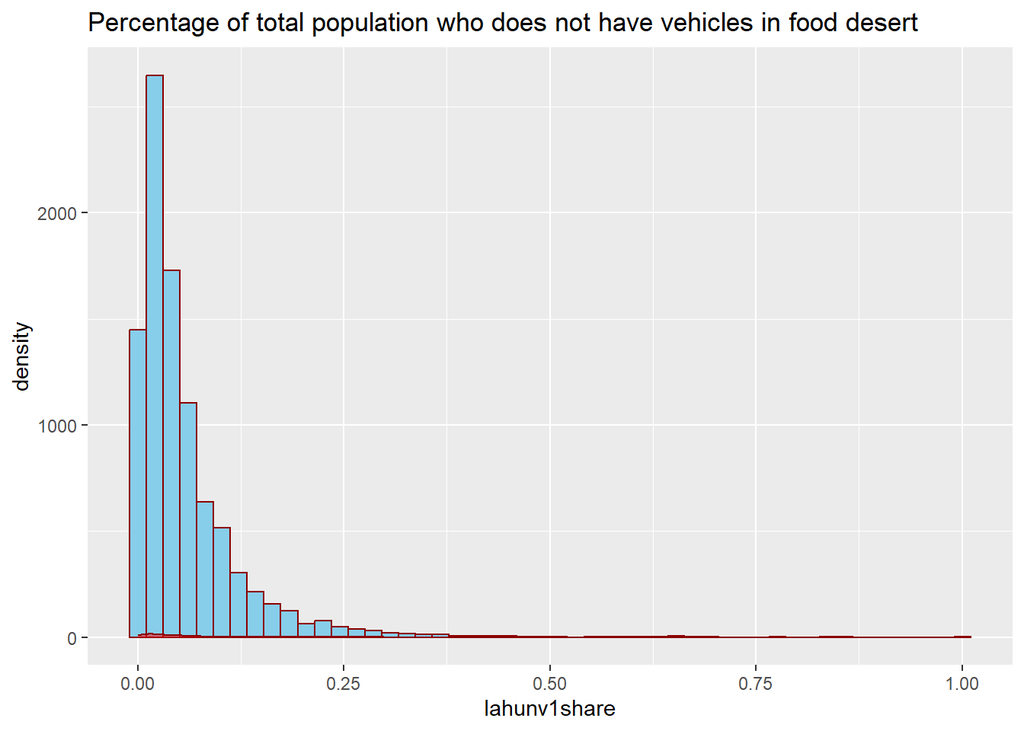

```r
data %>%
  filter(LILATracts_1And10 == 1) %>%
  ggplot(aes(x = lahunv1share)) +
  geom_histogram(bins = 50,fill = "skyblue", color="darkred") +
  geom_density(alpha = 0.5,fill= "red", color="darkred") +
  labs(title = "Percentage of total population who does not have vehicles in food desert")
```

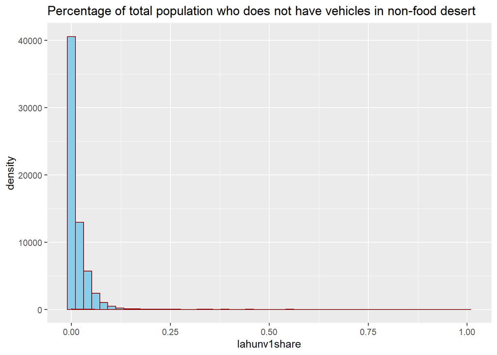

```r
data %>%
  filter(LILATracts_1And10 == 0) %>%
  ggplot(aes(x = lahunv1share)) +
  geom_histogram(bins = 50,fill = "skyblue", color="darkred") +
  geom_density(alpha = 0.5,fill= "red", color="darkred") +
  labs(title = "Percentage of total population who does not have vehicles in non-food desert")
```

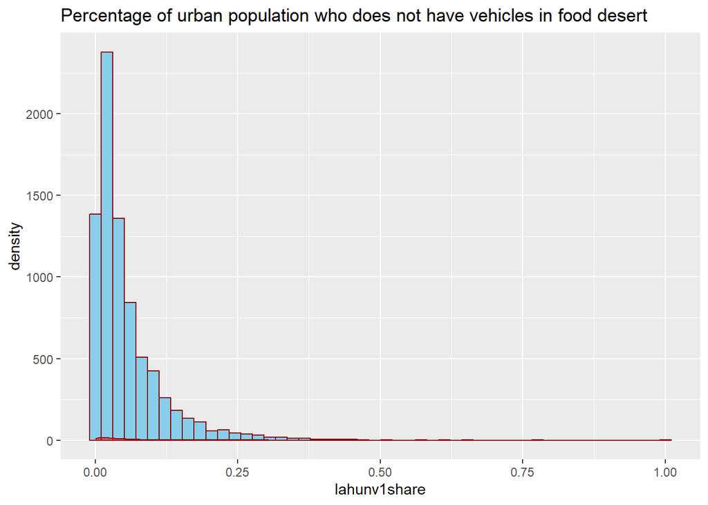

```r
data %>%
  filter(LILATracts_1And10 == 1 & Urban == 1) %>%
  ggplot(aes(x = lahunv1share)) +
  geom_histogram(bins = 50,fill = "skyblue", color="darkred") +
  geom_density(alpha = 0.5,fill = "red", color="darkred") +
  labs(title = "Percentage of urban population who does not have vehicles in food desert")
```

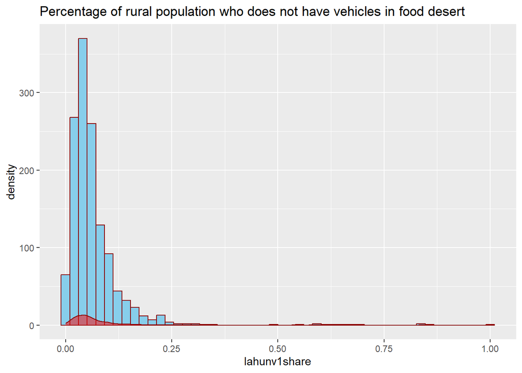

```r
data %>%
  filter(LILATracts_1And10 == 1 & Urban == 0) %>%
  ggplot(aes(x = lahunv1share)) +
  geom_histogram(bins = 50,fill = "skyblue", color="darkred") +
  geom_density(alpha = 0.5,fill = "red", color="darkred") +
  labs(title = "Percentage of rural population who does not have vehicles in food desert")
```

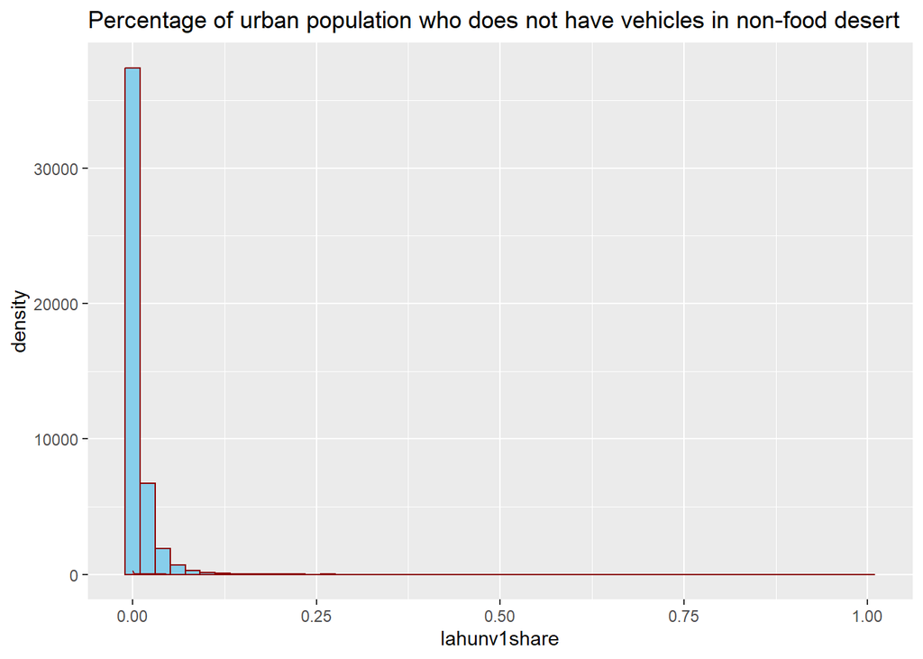

```r
data %>%
  filter(LILATracts_1And10 == 0 & Urban == 1) %>%
  ggplot(aes(x = lahunv1share)) +
  geom_histogram(bins = 50,fill = "skyblue", color="darkred") +
  geom_density(alpha = 0.5,fill = "red", color="darkred") +
  labs(title = "Percentage of urban population who does not have vehicles in non-food desert")
```

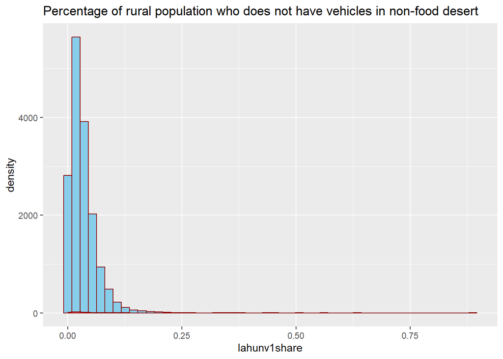

```r
data %>%
  filter(LILATracts_1And10 == 0 & Urban == 0) %>%
  ggplot(aes(x = lahunv1share)) +
  geom_histogram(bins = 50,fill = "skyblue", color="darkred") +
  geom_density(alpha = 0.5,fill = "red", color="darkred") +
  labs(title = "Percentage of rural population who does not have vehicles in non-food desert")
```

```r
result <- data %>%
  filter(LILATracts_1And10 == 1) %>%
  group_by(Urban) %>%
  summarise(
    lahunv1share_mean = mean(lahunv1share, na.rm = TRUE),
    lahunv10share_mean = mean(lahunv10share, na.rm = TRUE)
  )

print(result)
```

```
## # A tibble: 2 × 3
##   Urban lahunv1share_mean lahunv10share_mean
##   <fct>             <dbl>              <dbl>
## 1 0                0.0668           0.0408
## 2 1                0.0546           0.000162
```

```r
fd_urban = subset(result, Urban == 1)["lahunv1share_mean"] * 100
fd_rural = subset(result, Urban == 0)["lahunv10share_mean"] * 100
fd_vehicle = 100 - fd_urban + fd_urban
```

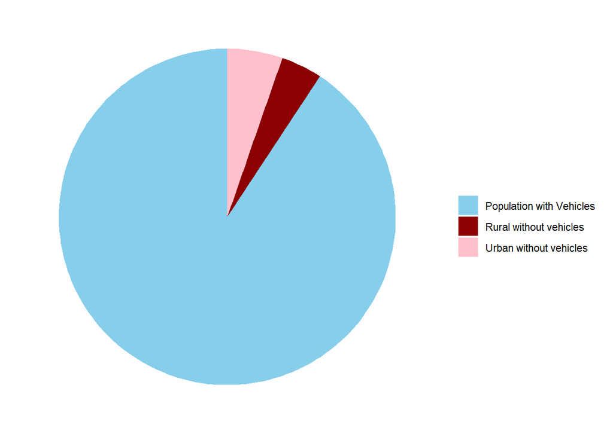

```r
data_pie <- data.frame(
  Category = c("Urban without vehicles", "Rural without vehicles", "Population with Vehicles"),
  Percentage = c(result[[2, "lahunv1share_mean"]] * 100 ,result[[1, "lahunv10share_mean"]] * 100, 100 - (result[[1, "lahunv1share_mean"]]  + result[[2, "lahunv10share_mean"]])* 100)
)
#print(data_pie)
# Generate the pie chart
ggplot(data_pie, aes(x = "", y = Percentage, fill = Category)) +
  geom_bar(stat = "identity", width = 1) +
  coord_polar("y", start=0) +
  theme_minimal() +
  theme(
    axis.text.x = element_blank(),
    axis.title.x = element_blank(),
    axis.title.y = element_blank(),
    panel.border = element_blank(),
    panel.grid=element_blank(),
    axis.ticks = element_blank(),
    plot.title=element_text(size=14, face="bold")
  ) +
  labs(fill = "") +
  scale_fill_manual(values = c("skyblue", "darkred", "pink"))
```

Around 5% urban population in food desert doesn’t have vehicles. Around 4% rural population in food desert doesn’t have vehicles. 91% population in food desert have vehicles.

### Share of population without vehicles - boxplots

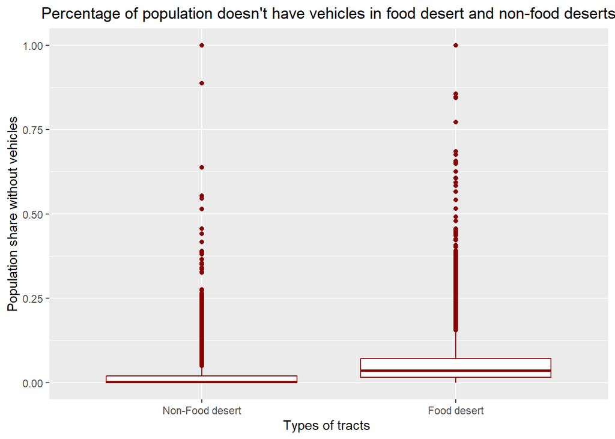

```r
data$LILATracts_1And10 <- as.factor(data$LILATracts_1And10)


levels(data$LILATracts_1And10) <- c("Non-Food desert", "Food desert")

ggplot(data = data,
       aes(x = LILATracts_1And10, y =lahunv1share)) +
      geom_boxplot(fill='white', color="darkred") +
      labs(title="Percentage of population doesn't have vehicles in food desert and non-food deserts",
      x ="Types of tracts ", y = "Population share without vehicles") +
      theme(plot.title = element_text(hjust = 0.5))
```

Seems like there is a lot of outliers in the data to make any conclusions. So removed outliers using KD2 method.

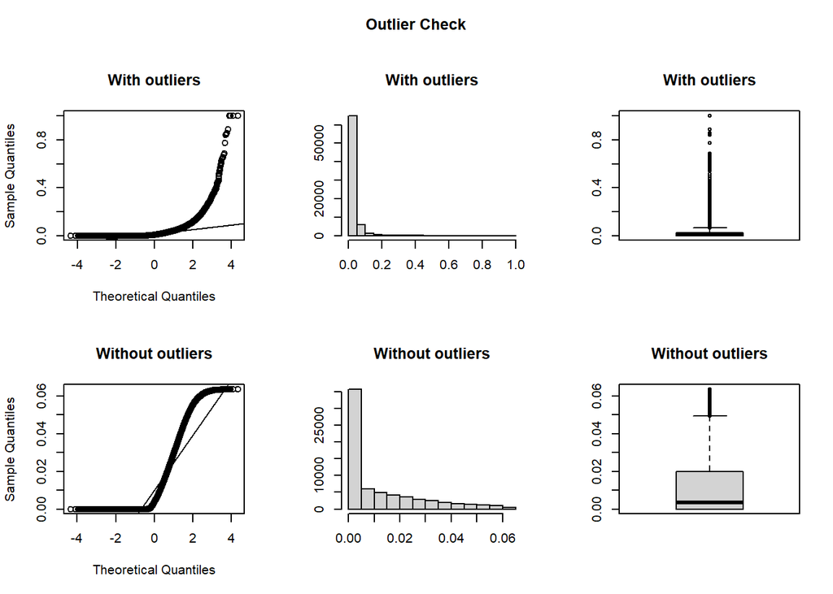

```
## Outliers identified: 5321
## Proportion (%) of outliers: 7.9
## Mean of the outliers: 0.11
## Mean without removing outliers: 0.02
## Mean if we remove outliers: 0.01
## Outliers successfully removed
```

```r
app_wo_gre_outlier <- ezids::outlierKD2(data, lahunv1share ,qqplt= TRUE, boxplt= TRUE, rm = TRUE)
```

```r
#str(app_wo_gre_outlier)
#gre_na = sum(is.na(app_wo_gre_outlier$gre))
```

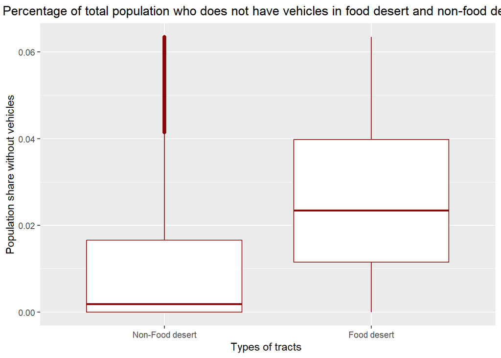

```r
app_wo_gre_outlier$LILATracts_1And10 <- as.factor(app_wo_gre_outlier$LILATracts_1And10)


levels(app_wo_gre_outlier$LILATracts_1And10) <- c("Non-Food desert", "Food desert")

ggplot(data = app_wo_gre_outlier,
       aes(x = LILATracts_1And10, y =lahunv1share)) +
      geom_boxplot(fill='white', color="darkred") +
      labs(title="Percentage of total population who does not have vehicles in food desert and non-food deserts",
      x ="Types of tracts ", y = "Population share without vehicles") +
      theme(plot.title = element_text(hjust = 0.5))
```

- A higher percentage of the population in food deserts lack vehicles compared to those in non-food desert.
- This could be concerning, as people in food deserts without vehicles may have even more difficulty accessing fresh and healthy food.

**Observations from the box plot**

The entire box (representing the middle 50% of the data) for the “food desert” category is higher on the y-axis compared to the “non-food desert” category. This indicates that a larger share of the population in food deserts typically lacks vehicles compared to those in non-food deserts. This could be concerning, as people in food deserts without vehicles may have even more difficulty accessing fresh and healthy food.

### Vehicle access in rural and urban tracts

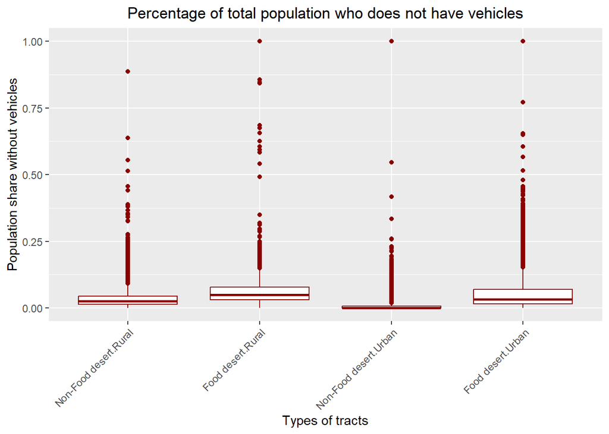

```r
data$Urban <- as.factor(data$Urban)
levels(data$Urban) <- c("Rural", "Urban")
ggplot(data = data,
       aes(x = interaction(LILATracts_1And10, Urban), y = lahunv1share)) +
  geom_boxplot(fill='white', color="darkred") +
  labs(title="Percentage of total population who does not have vehicles",
       x ="Types of tracts", y = "Population share without vehicles") +
  theme(plot.title = element_text(hjust = 0.5),
        axis.text.x = element_text(angle = 45, hjust = 1))
```

Seems like there is a lot of outliers in the data to make any conclusions. So let’s use outlier removed data.

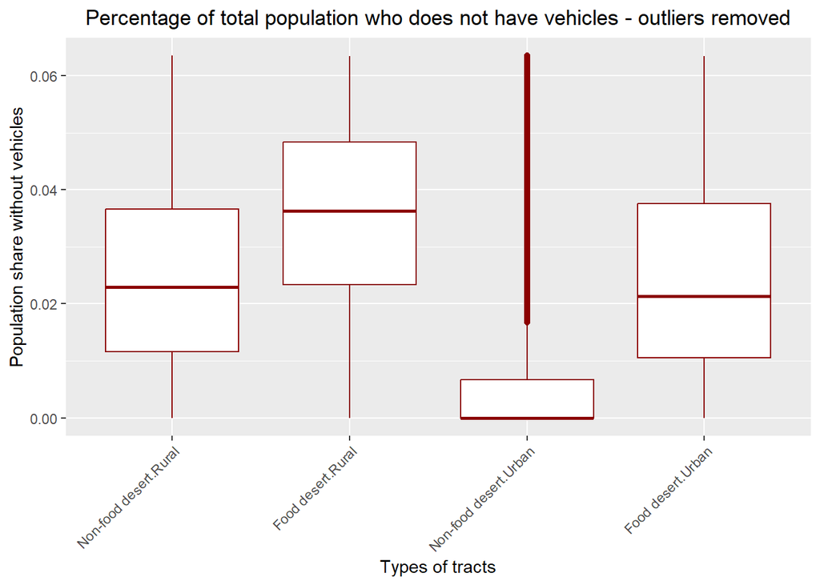

```r
app_wo_gre_outlier$Urban <- as.factor(app_wo_gre_outlier$Urban)
levels(app_wo_gre_outlier$Urban) <- c("Rural", "Urban")

app_wo_gre_outlier$LILATracts_1And10 <- as.factor(app_wo_gre_outlier$LILATracts_1And10)
levels(app_wo_gre_outlier$LILATracts_1And10) <- c("Non-food desert", "Food desert")
ggplot(data = app_wo_gre_outlier,
       aes(x = interaction(LILATracts_1And10, Urban), y = lahunv1share)) +
  geom_boxplot(fill='white', color="darkred") +
  labs(title="Percentage of total population who does not have vehicles - outliers removed",
       x ="Types of tracts", y = "Population share without vehicles") +
  theme(plot.title = element_text(hjust = 0.5),
        axis.text.x = element_text(angle = 45, hjust = 1))
```

`Analysis`

- Urban Areas:

The non-food desert urban areas have the smallest median percentage of people without vehicle access. This is likely because urban areas often have alternative modes of transportation, such as public transit, walking, or biking, making vehicle ownership less necessary. Moreover, urban areas often have amenities and services within walking distance, further reducing the need for a vehicle.

- Impact of Food Deserts:

In both rural and urban contexts, food deserts show a higher median percentage of people without vehicle access compared to non-food deserts. This is a significant concern because it suggests that people in food deserts, who already might have limited access to healthy food options, might also face transportation challenges.

- Rural vs. Urban:

While non-food desert urban areas have the lowest median percentage of people without vehicle access, food desert rural areas have the highest. This highlights the impact of food desert status on transportation barriers, irrespective of the urban or rural context.

## Question 6:

Income-related Variables and Food Deserts

### Visualizing Median Family Income

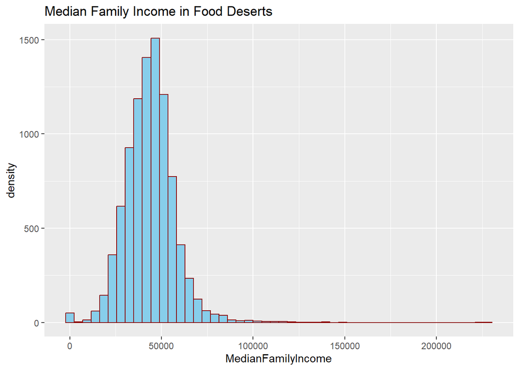

```r
data %>%
  filter(LILATracts_1And10 == "Food desert") %>%
  ggplot(aes(x = MedianFamilyIncome)) +
  geom_histogram(bins = 50, fill='skyblue', color="darkred") +  # Changed colors here
  geom_density(alpha = 0.8, fill="red", color="darkred") +      # And here
  labs(title = "Median Family Income in Food Deserts")
```

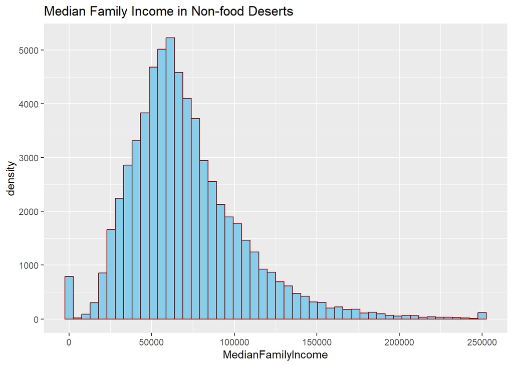

```r
data %>%
  filter(LILATracts_1And10 == "Non-Food desert") %>%
  ggplot(aes(x = MedianFamilyIncome)) +
  geom_histogram(bins = 50, fill='skyblue', color="darkred") +  # Changed colors here
  geom_density(alpha = 0.5, fill = "red", color="darkred") +      # And here
  labs(title = "Median Family Income in Non-food Deserts")
```

### Median income in food desert - boxplots

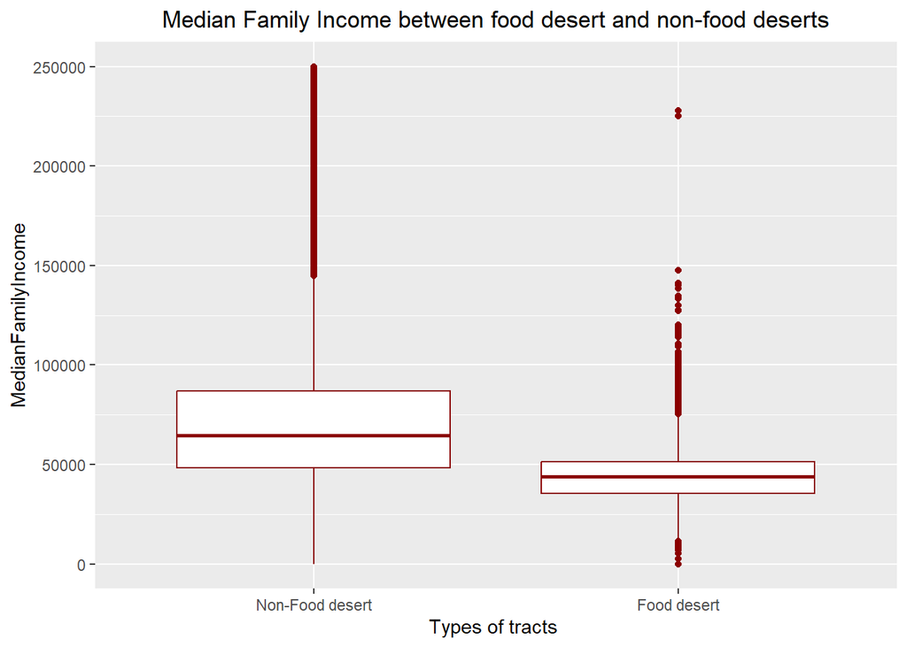

```r
data$LILATracts_1And10 <- as.factor(data$LILATracts_1And10)


levels(data$LILATracts_1And10) <- c("Non-Food desert", "Food desert")

ggplot(data = data,
       aes(x = LILATracts_1And10, y = MedianFamilyIncome)) +
      geom_boxplot(fill='white', color="darkred") +
      labs(title="Median Family Income between food desert and non-food deserts",
      x ="Types of tracts ", y = "MedianFamilyIncome") +
      theme(plot.title = element_text(hjust = 0.5))
```

- Confidence Interval tests

```r
fd_data <- subset(data, data$LILATracts_1And10 == "Food desert")

non_fd_data <- subset(data, data$LILATracts_1And10 == "Non-Food desert")
#print(fd_data)
ttest_fd_medincome_95 = t.test(x=fd_data$MedianFamilyIncome, conf.level=0.95 )
ttest_non_fd_medincome_95 = t.test(x=non_fd_data$MedianFamilyIncome, conf.level=0.95 )

print(ttest_fd_medincome_95)
```

```
##
##  One Sample t-test
##
## data:  fd_data$MedianFamilyIncome
## t = 307, df = 9244, p-value <2e-16
## alternative hypothesis: true mean is not equal to 0
## 95 percent confidence interval:
##  43566 44127
## sample estimates:
## mean of x
##     43847
```

```r
print(ttest_non_fd_medincome_95)
```

```
##
##  One Sample t-test
##
## data:  non_fd_data$MedianFamilyIncome
## t = 514, df = 63618, p-value <2e-16
## alternative hypothesis: true mean is not equal to 0
## 95 percent confidence interval:
##  70589 71129
## sample estimates:
## mean of x
##     70859
```

- T-intervals for the median income

- T-intervals for the median income in non-food desert

The difference in the intervals indicates the median income between food desert and non-food desert is different.

- ANOVA ON median income

Null hypothesis : There is no difference in the median income between food desert and non-food desert Alternate hypothesis : There is difference in the median income between food desert and non-food desert

```r
med_income_aov = aov(MedianFamilyIncome ~ LILATracts_1And10, data = data)
# plant_aov  # this does not give the easy-to-read result of the aov analysis
# summary(plant_aov)
plantaovsummary = summary(med_income_aov)
plantaovsummary
```

```
##                      Df   Sum Sq  Mean Sq F value Pr(>F)
## LILATracts_1And10     1 5.89e+12 5.89e+12    5448 <2e-16 ***
## Residuals         72862 7.88e+13 1.08e+09
## ---
## Signif. codes:  0 '***' 0.001 '**' 0.01 '*' 0.05 '.' 0.1 ' ' 1
```

At level of significance alpha set at = 0.05, as The p-value 2e-16 is less than the 0.05, we reject the null hypothesis “There is no difference in the median income between food desert and non-food desert” Given the large F value and the extremely low p-value, we can be confident in this result.

The anova results tell us that there is statistically significant difference in median income among food desert and non -deserts.

- Post-hoc Tukey HSD

```r
tukeyAoV <- TukeyHSD(med_income_aov)
tukeyAoV
```

```
##   Tukey multiple comparisons of means
##     95% family-wise confidence level
##
## Fit: aov(formula = MedianFamilyIncome ~ LILATracts_1And10, data = data)
##
## $LILATracts_1And10
##                               diff    lwr    upr p adj
## Food desert-Non-Food desert -27012 -27730 -26295     0
```

The post-hoc test confirms that families living in food deserts have a significantly lower median income compared to those not living in food deserts.

### Median Family Income in urban and rural areas

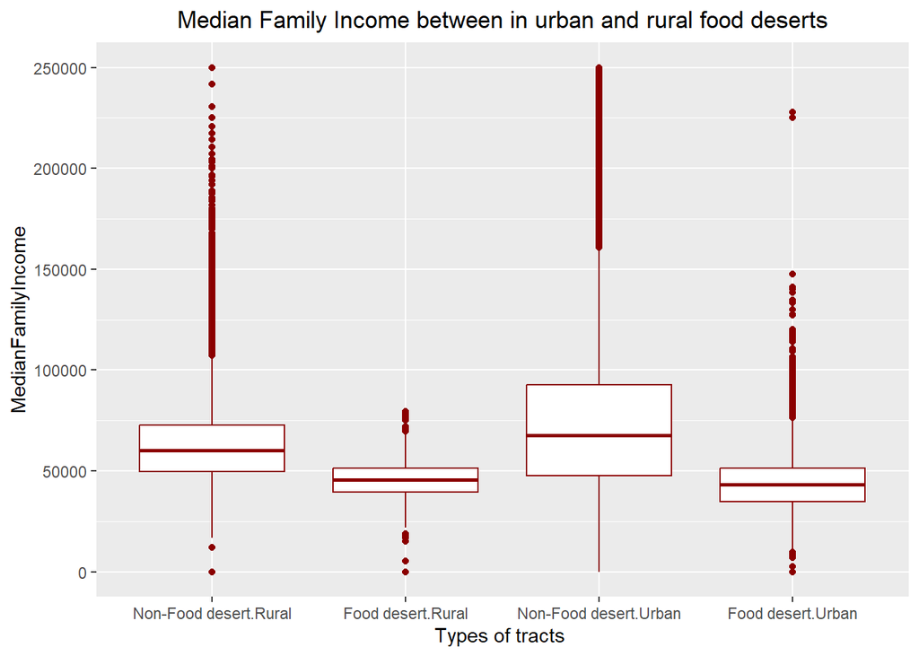

```r
data$LILATracts_1And10 <- as.factor(data$LILATracts_1And10)
levels(data$LILATracts_1And10) <- c("Non-Food desert", "Food desert")

data$Urban <- as.factor(data$Urban)
levels(data$Urban) <- c("Rural", "Urban")
ggplot(data = data,
       aes(x = interaction(LILATracts_1And10, Urban), y = MedianFamilyIncome)) +
      geom_boxplot(fill='white', color="darkred") +
      labs(title="Median Family Income between in urban and rural food deserts",
      x ="Types of tracts ", y = "MedianFamilyIncome") +
      theme(plot.title = element_text(hjust = 0.5))
```

**Urban**: As expected Non-food deserts in urban have higher median income than others.

**Rural**:Contrary to common perceptions, rural food deserts appear to have median family income similar to the urab food deserts.This suggest that the food desert in the rural areas is not solely due to economic reasons but could be influenced by other factors like distribution logistics, infrastructure, or availability of food retailers.

## Question 7

```r
dfFD = subset(data)

fooddesert_LILATracts_1And10_access = data.frame(dfFD$LILATracts_1And10 == 1)
fooddesert_LILATracts_1And10_access = dfFD%>%
  filter(LILATracts_1And10==1)

fooddesert_LILATracts_1And10_nonaccess = data.frame(dfFD$LILATracts_1And10 == 0)
fooddesert_LILATracts_1And10_nonaccess = dfFD%>%
  filter(LILATracts_1And10==0)

fooddesert_LILATracts_1And20_access = data.frame(dfFD$LILATracts_1And20 == 1)
fooddesert_LILATracts_1And20_access = dfFD%>%
  filter(LILATracts_1And20==1)

fooddesert_LILATracts_1And20_nonaccess = data.frame(dfFD$LILATracts_1And20 == 0)
fooddesert_LILATracts_1And20_nonaccess = dfFD%>%
  filter(LILATracts_1And20==0)
```

## Question 8:

Are the patterns in the prevalence of food deserts in these categories?

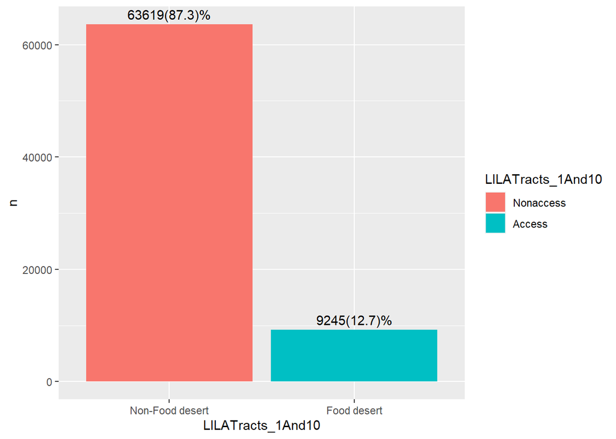

```r
library(ggplot2)

library(tidyverse)
fg <- data %>%
  count(LILATracts_1And10) %>%
  mutate(
    perc = round(proportions(n) * 100, 1),
    res = str_c(n, "(", perc, ")%"),
    LILATracts_1And10 = as.factor(LILATracts_1And10)
    )

ggplot(fg, aes(LILATracts_1And10, n, fill = LILATracts_1And10)) +
  geom_col() +
  geom_text(aes(label = res), vjust = -0.5) + scale_fill_discrete(labels = c("Nonaccess", "Access"))
```

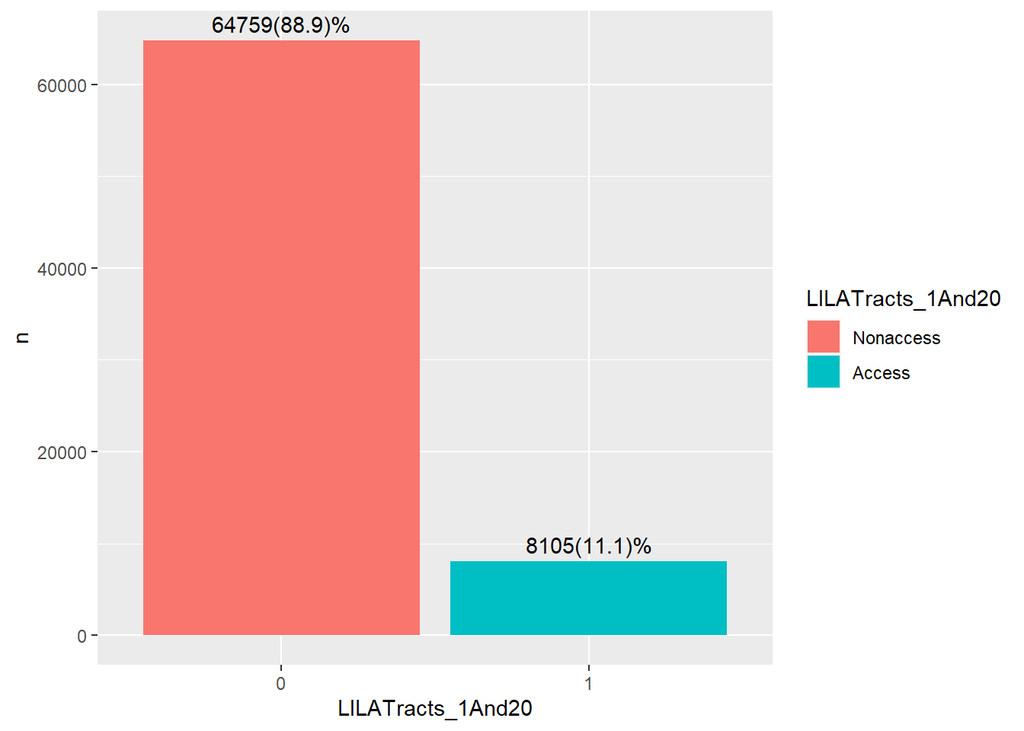

```r
fg1 <- data %>%
  count(LILATracts_1And20) %>%
  mutate(
    perc = round(proportions(n) * 100, 1),
    res = str_c(n, "(", perc, ")%"),
    LILATracts_1And20 = as.factor(LILATracts_1And20)
    )

ggplot(fg1, aes(LILATracts_1And20, n, fill = LILATracts_1And20)) +
  geom_col() +
  geom_text(aes(label = res), vjust = -0.5) + scale_fill_discrete(labels = c("Nonaccess", "Access"))
```

## Question 9

### Different Demographic groups in Food deserted Tracts:

Food Deserts impact in demographic groups of the society.

```r
levels(data$LILATracts_1And10) <- c(0, 1)
levels(data$Urban) <- c(0, 1)
LILA_df <- data[data$LILATracts_1And10 == 1,]
LILA_Urban <- LILA_df[LILA_df$Urban == 1,]
LILA_Rural <- LILA_df[LILA_df$Urban == 0,]

Percentage_LILA_White <- ((sum(LILA_Urban$lawhite1) + sum(LILA_Rural$lawhite10))/sum(data$TractWhite))*100
Percentage_LILA_Black <- ((sum(LILA_Urban$lablack1) + sum(LILA_Rural$lablack10))/sum(data$TractBlack))*100
Percentage_LILA_Asian <- ((sum(LILA_Urban$laasian1) + sum(LILA_Rural$laasian10))/sum(data$TractAsian))*100
Percentage_LILA_Hisp <- ((sum(LILA_Urban$lahisp1) + sum(LILA_Rural$lahisp10))/sum(data$TractHispanic))*100
Percentage_LILA_Hopi <- ((sum(LILA_Urban$lanhopi1) + sum(LILA_Rural$lanhopi10))/sum(data$TractNHOPI))*100
Percentage_LILA_Multir <- ((sum(LILA_Urban$laomultir1) + sum(LILA_Rural$laomultir10))/sum(data$TractOMultir))*100
Percentage_LILA_Aian <- ((sum(LILA_Urban$laaian1) + sum(LILA_Rural$laaian10))/sum(data$TractAIAN))*100

data3 = data.frame()
data3 <- rbind(data3, Percentage_LILA_White)
data3 <- rbind(data3, Percentage_LILA_Black)
data3 <- rbind(data3, Percentage_LILA_Asian)
data3 <- rbind(data3, Percentage_LILA_Hisp)
data3 <- rbind(data3, Percentage_LILA_Hopi)
data3 <- rbind(data3, Percentage_LILA_Multir)
data3 <- rbind(data3, Percentage_LILA_Aian)
Groups = c("White", "Black", "Asian", "Hisp", "Hopi", "OMultir", "Aian")
data3 <- cbind(data3, Groups)
colnames(data3) <- c('Percentage', 'Groups')
```

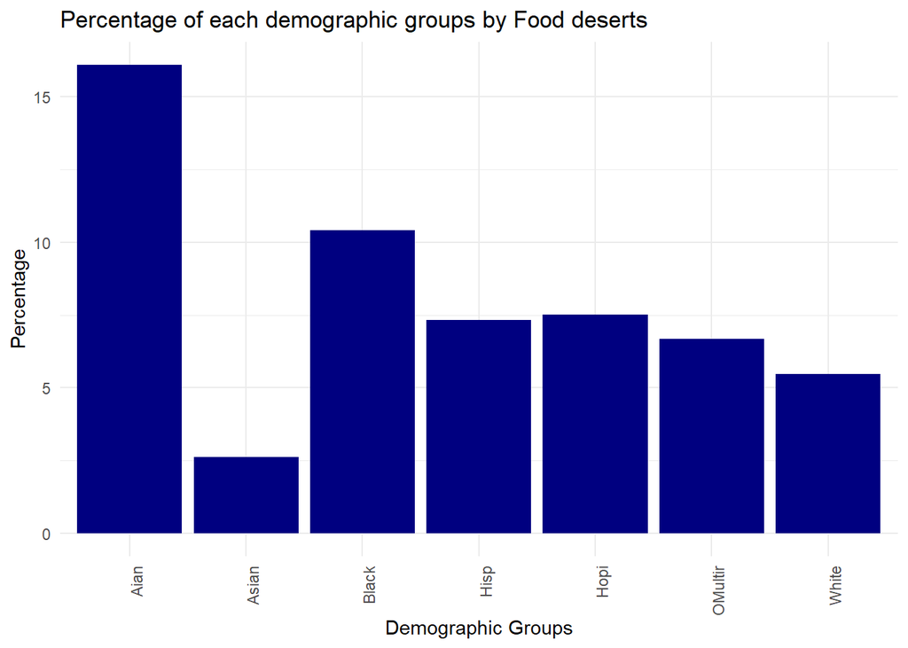

```r
bar_chart <- ggplot(data3, aes(x = Groups, y = Percentage)) +
  geom_bar(stat = "identity", fill = "navy") +
  labs(title = "Percentage of each demographic groups by Food deserts",
       x = "Demographic Groups",
       y = "Percentage") +
  theme_minimal() +
  theme(axis.text.x = element_text(angle = 90, hjust = 1, vjust=1))

print(bar_chart)
```

AIAN - American Indian or Alaska Native

HOPI - Native Hawaiian or Other Pacific Islander

OMultir - other/multiple race

HISP - Hispanic or Latino.

- **we can see from the chart that *AIAN* and *Black* neighborhoods are more likely to lack access to supermarkets than other groups.**
- **And the least is *Asian* group.**
- **This prompts the question of whether “food deserts” are a result of structural racial inequity.**

### Food access to vulnerable age groups of society:

- Pie chart of Kids in food deserts and non food deserts.

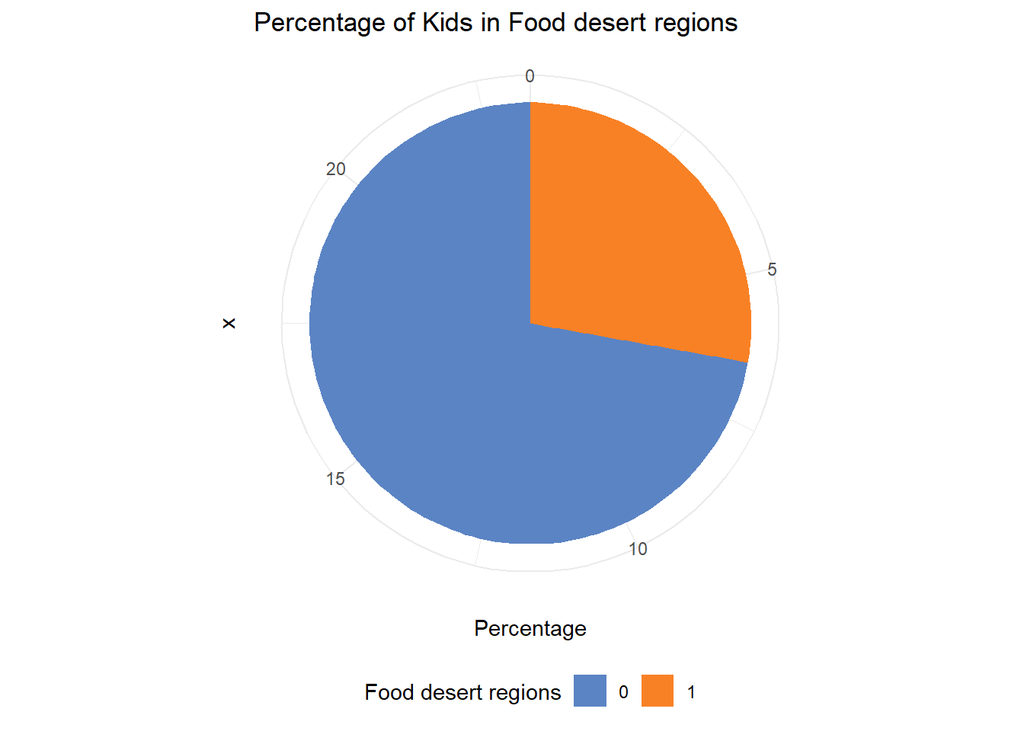

```r
LILA_df <- data[data$LILATracts_1And10 == 1,]
LILA_Urban <- LILA_df[LILA_df$Urban == 1,]
LILA_Rural <- LILA_df[LILA_df$Urban == 0,]

Percentage_LILA_kids <- ((sum(LILA_Urban$lakids1) + sum(LILA_Rural$lakids10))/sum(data$TractKids))*100

NonLILA_df <- data[data$LILATracts_1And10 == 0,]
NonLILA_Urban <- NonLILA_df[NonLILA_df$Urban == 1,]
NonLILA_Rural <- NonLILA_df[NonLILA_df$Urban == 0,]

Percentage_NonLILA_kids <- ((sum(NonLILA_Urban$lakids1) + sum(NonLILA_Rural$lakids10))/sum(data$TractKids))*100


data5 = data.frame()
data5 <- rbind(data5, Percentage_LILA_kids)
data5 <- rbind(data5, Percentage_NonLILA_kids)

LILA = c(1,0)
data5 <- cbind(data5, LILA)
colnames(data5) <- c('Percentage', 'LILA')

pie_chart <- ggplot(data5, aes(x = "", y = Percentage, fill = factor(LILA))) +
  geom_bar(stat = "identity", width = 1) +
  coord_polar(theta = "y") +
  labs(title = "Percentage of Kids in Food desert regions",
       fill = "Food desert regions") +
  scale_fill_manual(values = c("0" = "#5b84c4", "1" = "#F98125"), labels = c("0", "1")) +
  theme_minimal() +
  theme(legend.position = "bottom")
print(pie_chart)
```

- Pie chart of Seniors in food deserts and non food deserts.

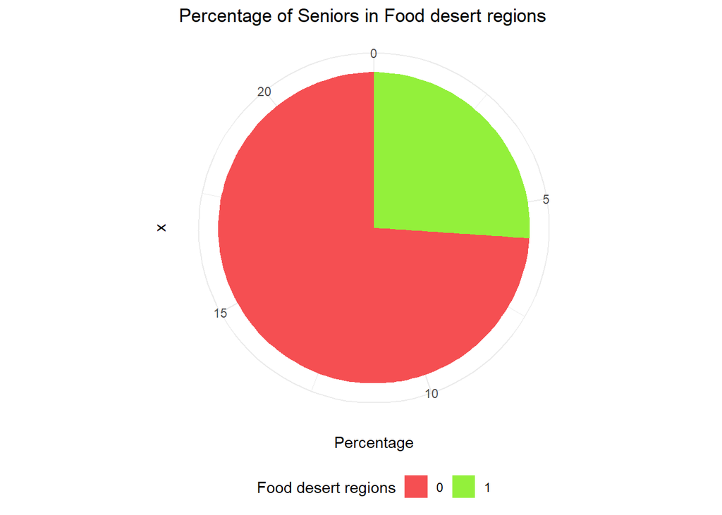

```r
Percentage_LILA_Seniors <- ((sum(LILA_Urban$laseniors1) + sum(LILA_Rural$laseniors10))/sum(data$TractSeniors))*100

Percentage_NonLILA_Seniors <- ((sum(NonLILA_Urban$laseniors1) + sum(NonLILA_Rural$laseniors10))/sum(data$TractSeniors))*100


data6 = data.frame()
data6 <- rbind(data6, Percentage_LILA_Seniors)
data6 <- rbind(data6, Percentage_NonLILA_Seniors)

LILA = c(1,0)
data6 <- cbind(data6, LILA)
colnames(data6) <- c('Percentage', 'LILA')

pie_chart <- ggplot(data6, aes(x = "", y = Percentage, fill = factor(LILA))) +
  geom_bar(stat = "identity", width = 1) +
  coord_polar(theta = "y") +
  labs(title = "Percentage of Seniors in Food desert regions",
       fill = "Food desert regions") +
  scale_fill_manual(values = c("0" = "#F54F52", "1" = "#93F03B"), labels = c("0", "1")) +
  theme_minimal() +
  theme(legend.position = "bottom")
print(pie_chart)
```

**From these pie charts we can view that both kids and seniors live more in non-deserted regions.**

**Are they intentionally choosing neighborhoods near supermarkets which limits the opportunity for other groups to live better?**

## Question 10

### Loading 2010 Dataset:

```r
df2010 = data.frame(read.csv("food_access_research_atlas_2010.csv"))
knitr::kable(head(df2010, 5), format ='markdown')
```

| CensusTract | State | County | LILATracts_1And10 | LILATracts_halfAnd10 | LILATracts_1And20 | LILATracts_Vehicle | Urban | Rural | LA1and10 | LAhalfand10 | LA1and20 | LATracts_half | LATracts1 | LATracts10 | LATracts20 | LATractsVehicle_20 | HUNVFlag | GroupQuartersFlag | OHU2010 | NUMGQTRS | PCTGQTRS | LowIncomeTracts | POP2010 | UATYP10 | lapophalf | lapophalfshare | lalowihalf | lalowihalfshare | lakidshalf | … |
| --- | --- | --- | --- | --- | --- | --- | --- | --- | --- | --- | --- | --- | --- | --- | --- | --- | --- | --- | --- | --- | --- | --- | --- | --- | --- | --- | --- | --- | --- | --- |
| 3.6005e+10 | NY | Bronx | 0 | 0 | 0 | 0 | 1 | 0 | 0 | 0 | 0 | 0 | 0 | 0 | 0 | 0 | 0 | 0 | 3019 | 0 | 0 | 1 | 8731 | U | 0 | 0 | 0 | 0 | 0 | … |
| 3.6005e+10 | NY | Bronx | 0 | 0 | 0 | 0 | 1 | 0 | 0 | 0 | 0 | 0 | 0 | 0 | 0 | 0 | 0 | 0 | 1824 | 0 | 0 | 1 | 5491 | U | 0 | 0 | 0 | 0 | 0 | … |
| 3.6005e+10 | NY | Bronx | 0 | 0 | 0 | 0 | 1 | 0 | 0 | 0 | 0 | 0 | 0 | 0 | 0 | 0 | 0 | 0 | 1042 | 0 | 0 | 1 | 3113 | U | 0 | 0 | 0 | 0 | 0 | … |
| 3.6005e+10 | NY | Bronx | 0 | 0 | 0 | 0 | 1 | 0 | 0 | 0 | 0 | 0 | 0 | 0 | 0 | 0 | 0 | 0 | 513 | 0 | 0 | 1 | 1597 | U | 0 | 0 | 0 | 0 | 0 | … |
| 3.6005e+10 | NY | Bronx | 0 | 0 | 0 | 0 | 1 | 0 | 0 | 0 | 0 | 0 | 0 | 0 | 0 | 0 | 0 | 0 | 1092 | 0 | 0 | 1 | 3413 | U | 0 | 0 | 0 | 0 | 0 | … |